# Europeean Materials Modelling Ontology

### Version 1.0.0-alpha2

### European Materials Modelling Counsil (EMMC)

October 14, 2020

**Abstract:**

EMMO is an ontology that is created by the [Europeean Materials Modelling Council (EMMC)](https://emmc.info/) to provide a formal way to describe the fundamental concepts of physics, chemistry and materials science. EMMO is designed to pave the road for semantic interoperability providing a generic common ground for describing materials, models and data that can be adapted by all domains.

It is a representational framework of predefined classes and axioms (ontology) provided by experts (EMMC) that enables end users (industry, research, academy) to represent real life physical entities (materials, devices), models and properties using ontological signs (individuals) in a standard way to facilitate interactions and exchanges (data, software, knowledge) between all involved material modelling and characterization communities and stakeholders.

**Authors:**  
*Emanuele Ghedini, University of Bologne*  
*Gerhard Goldbeck, Goldbeck Consulting*  
*Jesper Friis, SINTEF*  
*Adham Hashibon, Fraunhofer IWM*  
*Georg Schmitz, ACCESS*

**Content**

# Introduction

EMMO is a multidisciplinary effort to develop a standard representational framework (the ontology) based on current materials modelling knowledge, including physical sciences, analytical philosophy and information and communication technologies. This multidisciplinarity is illustrated by the figure on the title page. It provides the connection between the physical world, materials characterisation world and materials modelling world.

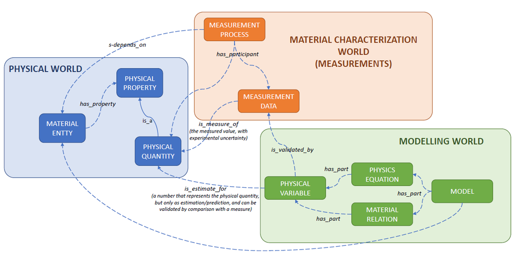

EMMO provides the connection between the physical world, materials characterisation world and materials modelling world.

EMMO is based on and is consistent with the [Review of Materials Modelling](https://publications.europa.eu/en/publication-detail/-/publication/ec1455c3-d7ca-11e6-ad7c-01aa75ed71a1), [CEN Workshop Agreement](https://www.cen.eu/news/workshops/Pages/WS_2016-013.aspx) and [MODA template](https://emmc.info/moda-workflow-templates/). However, while these efforts are written for humans, EMMO is defined using the [Web Ontology Language (OWL)](https://en.wikipedia.org/wiki/Web_Ontology_Language), which is machine readable and allows for machine reasoning. In terms of semantic representation, EMMO brings everything to a much higher level than these foundations.

As illustrated in the figure below, EMMO covers all aspects of materials modelling and characterisation, including:

- the **material** itself, which must be described in a rigorous way
- the **observation process** involving an observer that percieves the real world (characterisation)
- the **properties** that are measured or modelled
- the **physics laws** that describe the material behaviour
- the **physical models** that approximate the physics laws
- the **solver** including the numerical discretisation method that leads to a solvable mathematical representation under certain simplifying assumptions
- the **numerical solver** that performs the calculations
- the **post processing** of experimental or simulated data

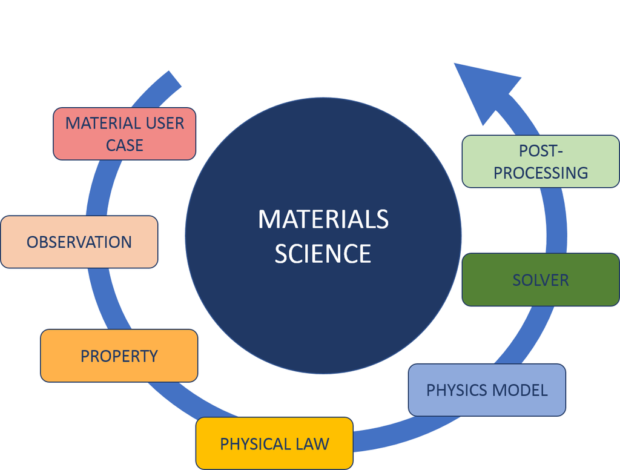

The aspects of materials modelling and characterisation covered by EMMO.

EMMO is released under the [Creative Commons license](http://emmo.info/blob/v1.0.0/LICENSE.md) and is available at [emmo.info/](https://github.com/emmo-repo/EMMO/). The OWL2-DL sources are available in RDF/XML format.

## What is an ontology

In short, an ontology is a specification of a conceptualization. The word *ontology* has a long history in philosophy, in which it refers to the subject of existence. The so-called [ontological argument](https://en.wikipedia.org/wiki/Ontological_argument) for the existence of God was proposed by Anselm of Canterbury in 1078. He defined God as *“that than which nothing greater can be thought”*, and argued that *“if the greatest possible being exists in the mind, it must also exist in reality. If it only exists in the mind, then an even greater being must be possible – one which exists both in the mind and in reality”*. Even though this example has little to do with todays use of ontologies in e.g. computer science, it illustrates the basic idea; the ontology defines some basic premises (concepts and relations between them) from which it is possible reason to gain new knowledge.

For a more elaborated and modern definition of the ontology we refer the reader to the one provided by [Tom Gruber (2009)](http://tomgruber.org/writing/ontology-definition-2007.htm). Another useful introduction to ontologies is the paper [Ontology Development 101: A Guide to Creating Your First Ontology](http://www.ksl.stanford.edu/people/dlm/papers/ontology-tutorial-noy-mcguinness-abstract.html) by Noy and McGuinness (2001), which is based on the [Protege](https://protege.stanford.edu/) sortware, with which EMMO has been developed.

A taxonomy is a hierarchical representation of classes and subclasses connected via `is_a` relations. Hence, it is a subset of the ontology excluding all but the `is_a` relations. The main use of taxonomies is for the organisation of classifications. The figure shows a simple example of a taxonomy illustrating a categorisation of four classes into a hierarchy of more higher of levels of generality.

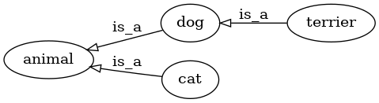

Example of a taxonomy.

In EMMO, the taxonomy is a rooted directed acyclic graph (DAG). This is important since many classification methods relies on this property, see e.g. [Valentini (2014)](https://arxiv.org/abs/1406.4472) and Robison et al (2015). Note, that EMMO is a DAG does not prevent some classes from having more than one parent. A `Variable` is for instance both a `Mathematical` and a `Symbol`. See appendix for the full EMMO taxonomy.

## Primitive elements in EMMO

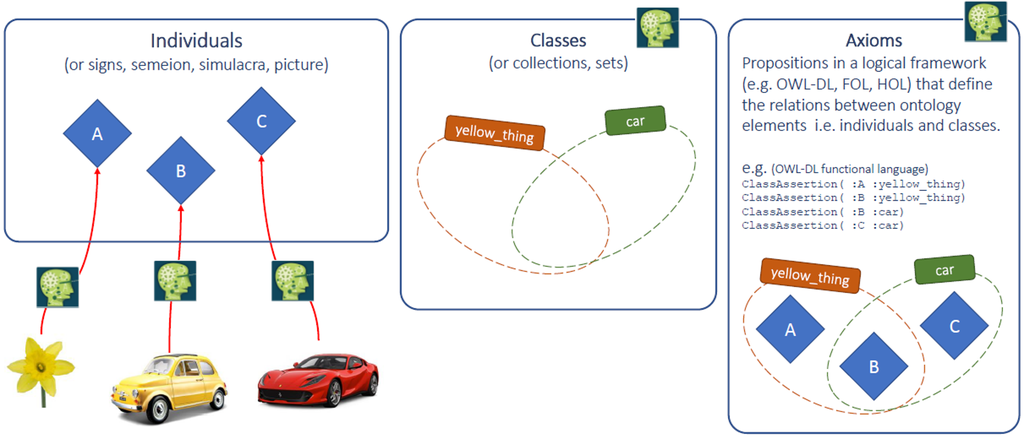

The primitive building blocks of EMMO.

### Individuals

Individuals are the basic, “ground level” components of EMMO. They may include concrete objects such as cars, flowers, stars, persons and molecules, as well as abstract individuals such as a measured height, a specific equation and software programs.

Individuals possess attributes in form of axioms that are defined by the user (interpreter) upon declaration.

### Classes

Classes represent concepts. They are the building blocks that we use to create an ontology as a representation of knowledge. We distinguish between *defined* and *non-defined* classes.

Defined classes are defined by the requirements for being a member of the class. In the graphical representations of EMMO, defined classes are orange. For instance, in the graph of the top-level entity branch below, The root `EMMO` and a defined class (defined to be the disjoint union of `Item` and `Collection`).

Non-defined classes are defined as an abstract group of objects, whose members are defined as belonging to the class. They are yellow in the graphical representations.

[figure not shown]

Example of the top-level branch of EMMO showing some classes and relationships between them.

### Axioms

Axioms are propositions in a logical framework that define the relations between the individuals and classes. They are used to categorise individuals in classes and to define the *defined* classes.

The simplest form of a class axiom is a class description that just states the existence of the class and gives it an unique identifier. In order to provide more knowledge about the class, class axioms typically contain additional components that state necessary and/or sufficient characteristics of the class. OWL contains three language constructs for combining class descriptions into class axioms:

- *Subclass* (`rdfs:subClassOf`) allows one to say that the class extension of a class description is a subset of the class extension of another class description.
- *Equivalence* (`owl:equivalentClass`) allows one to say that a class description has exactly the same class extension (i.e. the individuals associated with the class) as another class description.
- *Distjointness* (`owl:disjointWith`) allows one to say that the class extension of a class description has no members in common with the class extension of another class description.

See the section about Description logic for more information about these language constructs. Axioms are also used to define relations between relations. These are further detailed in the chapter on Relations.

## Theoretical foundations

EMMO build upon several theoretical frameworks.

### Semiotics

Semiotics is the study of meaning-making. It is the dicipline of formulating something that possibly can exist in a defined space and time in the real world.

### Mereotopology

Mereotopology is the combination of **mereology** (science of parthood) and **topology** (mathematical study of the geometrical properties and conservation through deformations). It is introdused via the `Item` class and based on the `mereotopological` relations. Items in EMMO are always topologically connected in space and time. EMMO makes a strong distinction between membership and parthood relations. In contrast to collections, items can only have parts that are themselves items. For further information, see [Casati and Varzi “Parts and Places” (1999)](https://mitpress.mit.edu/books/parts-and-places).

### Physics

EMMO is strongly based on physics, with the aim of being able to describe all aspects and all domains of physics, from quantum mechanics to continuum, engeneering, chemistry, etc. EMMO is compatible with both the De Broglie - Bohm and the Copenhagen interpretation of quantum mecanics (see `Physical` for more comments).

EMMO defines a physics-based parthood hierachy under `Physical` by introducing the following concepts (illustrated in the figure below):

- `Elementary` is the fundamental, non-divisible constituent of entities. In EMMO, elementaries are based on the standard model of physics.
- `State` is a `Physical` whose parts does not change during its life time (at the chosen level of granularity). This is consistent with a state within e.g. thermodynamics.
- `Existent` is a succession of states.

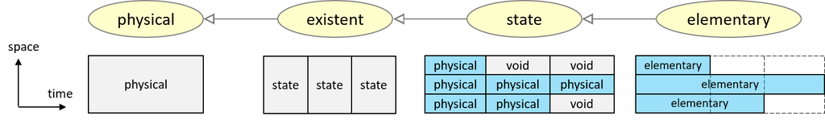

Parthood hierachy under `Physical`.

### Metrology

Metrology is the science of measurements. It introduces units and links them to properties. The description of metrology in EMMO is based on the standards of [International System of Quantities (ISQ)](https://en.wikipedia.org/wiki/International_System_of_Quantities) and [International System of Units (SI)](https://en.wikipedia.org/wiki/International_System_of_Units).

### Description logic

[Description logic (DL)](https://en.wikipedia.org/wiki/Description_logic) is a formal knowledge representation language in which the *axioms* are expressed. It is less expressive than [first-order logic (FOL)](https://en.wikipedia.org/wiki/First-order_logic), but commonly used for providing the logical formalism for ontologies and semantic web. EMMO is expressed in the [Web Ontology Language (OWL)](https://en.wikipedia.org/wiki/Web_Ontology_Language), which in turn is based on DL. This brings along features like reasoning.

Since it is essential to have a basic notion of OWL and DL, we include here a very brief overview. For a proper introduction to OWL and DL, we refer the reader to sources like [Grau et.al. (2008)](http://www.cs.ox.ac.uk/boris.motik/pubs/ghmppss08next-steps.pdf), [OWL2 Primer](https://www.w3.org/TR/owl2-primer/) and [OWL Reference](https://www.w3.org/TR/owl-ref/).

OWL distinguishes between six types of class descriptions:

1. a class identifier (a IRI reference)
2. an exhaustive enumeration of individuals that together form the instances of a class (`owl:oneOf`)
3. a property restriction (`owl:someValuesFrom`, `owl:allValuesFrom`, `owl:hasValue`, `owl:cardinality`, `owl:minCardinality`, `owl:maxCardinality`)
4. the intersection of two or more class descriptions (`owl:intersectionOf`)
5. the union of two or more class descriptions (`owl:unionOf`)
6. the complement of a class description (`owl:complementOf`)

Except for the first, all of these refer to *defined classes*. The table below shows the notation in OWL, DL and the [Manchester OWL syntax](http://ceur-ws.org/Vol-216/submission_9.pdf), all commonly used for the definitions. The Manchester syntax is used by [Protege](https://protege.stanford.edu/) and is designed to not use DL symbols and to be easy and quick to read and write. Several other syntaxes exist for DL. An interesting example is the pure Python syntax proposed by [Lamy (2017)](http://www.lesfleursdunormal.fr/_downloads/article_owlready_aim_2017.pdf), which is used in the open source [Owlready2](https://pythonhosted.org/Owlready2/) Python package. The [Python API for EMMO](https://github.com/emmo-repo/EMMO-python) is also based on Owlready2.

Notation for DL and Protege. *A* and *B* are classes, *R* is an active relation, *S* is an passive relation, *a* and *b* are individuals and *n* is a literal. Inspired by the [Great table of Description Logics](http://www.lesfleursdunormal.fr/static/_downloads/great_ontology_table.pdf).

| DL | Manchester | [Python + Owlready2](https://pythonhosted.org/Owlready2/) | Read | Meaning |
| --- | --- | --- | --- | --- |
| **Constants** |  |  |  |  |
| $⊤$ |  | Thing | top | A special class with every individual as an instance |
| $⊥$ |  | Nothing | bottom | The empty class |
| **Axioms** |  |  |  |  |
| *A* ≐ *B* |  |  | A is defined to be equal to B | Class *definition* |
| *A* ⊑ *B* | A subclass_of B | class A(B): … | all A are B | Class *inclusion* |
|  |  | issubclass(A, B) |  | Test for *inclusion* |
| *A* ≡ *B* | A equivalent_to B | A.equivalent_to.append(B) | A is equivalent to B | Class *equivalence* |
|  |  | B in A.equivalent_to |  | Test for equivalence |
| *a* : *A* | a is_a A | a = A() | a is a A | Class *assertion* (*instantiation*) |
|  |  | isinstance(a, A) |  | Test for instance of |
| (*a*, *b*) : *R* | a object property assertion b | a.R.append(b) | a is R-related to b | Property *assertion* |
| (*a*, *n*) : *R* | a data property assertion n | a.R.append(n) | a is R-related to n | Data *assertion* |
| **Constructions** |  |  |  |  |
| *A* ⊓ *B* | A and B | A & B | A and B | Class *intersection* (*conjunction*) |
| *A* ⊔ *B* | A or B | A \| B | A or B | Class *union* (*disjunction*) |
| ¬*A* | not A | Not(A) | not A | Class *complement* (*negation*) |
| {*a*, *b*, ...} | {a, b, …} | OneOf([a, b, …]) | one of a, b, … | Class *enumeration* |
| *S* ≡ *R*<sup>−</sup> | S inverse_of R | Inverse(R) | S is inverse of R | Property *inverse* |
|  |  | S.inverse == R |  | Test for *inverse* |
| ∀*R*.*A* | R only A | R.only(A) | all A with R | [*Universal restriction*](https://en.wikipedia.org/wiki/Universal_quantifier) |
| ∃*R*.*A* | R some A | R.some(A) | some A with R | [*Existential restriction*](https://en.wikipedia.org/wiki/Universal_quantifier) |
| = *n**R*.*A* | R exactly n A | R.exactly(n, A) |  | *Cardinality restriction* |
| ≤ *n**R*.*A* | R min n A | R.min(n, A) |  | *Minimum cardinality restriction* |
| ≥ *n**R*.*A* | R max n A | R.max(n, A) |  | *Minimum cardinality restriction* |
| ∃*R*{*a*} | R value a | R.value(a) |  | *Value restriction* |
| **Decompositions** |  |  |  |  |
| *A* ⊔ *B* ⊑ ⊥ | A disjoint with B | AllDisjoint([A, B]) | A disjoint with B | Disjoint |
|  |  | B in A.disjoints() |  | Test for disjointness |
| ∃*R*.⊤ ⊑ *A* | R domain A | R.domain = [A] |  | Classes that the restriction applies to |
| ⊤ ⊑ ∀*R*.*B* | R range B | R.range = [B] |  | All classes that can be the value of the restriction |

#### Examples

Here are some examples of different class descriptions using both the DL and Manchester notation.

##### Equivalence (`owl:equivalentTo`)

Equivalence ($≡$) defines necessary and sufficient conditions.

Parent is equivalent to mother or father

**DL:** `parent` $≡$ `mother` $∨$ `father`

**Manchester:** `parent equivalent_to mother or father`

##### Inclusion (`rdf:subclassOf`)

Inclusion ($⊑$) defines necessary conditions.

An employee is a person.

**DL:** `employee` $⊑$ `person`

**Manchester:** `employee is_a person`

##### Enumeration (`owl:oneOf`)

The color of a wine is either white, rose or red:

**DL:** `wine_color` $≡$ {`white`, `rose`, `red`}

**Manchester:** `wine_color equivalent_to {white, rose, red}`

##### Existential restriction (`owl:someValuesFrom`)

A mother is a woman that has a child (some person):

**DL:** `mother` $≡$ `woman` $⊓$ $∃$`has_child`.`person`

**Manchester:** `mother equivalent_to woman and has_child some person`

##### Universal restriction (`owl:allValuesFrom`)

All parents that only have daughters:

**DL:** `parents_with_only_daughters` $≡$ `person` $⊓$ $∀$`has_child`.`woman`

**Manchester:** `parents_with_only_daughters equivalent_to person and has_child only woman`

##### Value restriction (`owl:hasValue`)

The owl:hasValue restriction allows to define classes based on the existence of particular property values. There must be at least one matching property value.

All children of Mary:

**DL:** `Marys_children` $≡$ `person` $⊓$ $∃$`has_parent`.{`Mary`}

**Manchester:** `Marys_children equivalent_to person and has_parent value Mary`

##### Property cardinality (`owl:cardinality`)

The owl:cardinality restrictions ($≥$, $≤$ or $≡$) allow to define classes based on the maximum (owl:maxCardinality), minimum (owl:minCardinality) or exact (owl:cardinality) number of occurences.

A person with one parent:

**DL:** `half_orphant` $≡$ `person` and =1`has_parent`.`person`

**Manchester:** `half_orphant equivalent_to person and has_parent exactly 1 person`

##### Intersection (`owl:intersectionOf`)

Individuals of the intersection ($⊓$) of two classes, are simultaneously instances of both classes.

A man is a person that is male:

**DL:** `man` $≡$ `person` $⊓$ `male`

**Manchester:** `man equivalent_to person and male`

##### Union (`owl:unionOf`)

Individuals of the union ($⊔$) of two classes, are either instances of one or both classes.

A person is a man or woman:

**DL:** `person` $≡$ `man` $⊔$ `woman`

**Manchester:** `person equivalent_to man or woman`

##### Complement (`owl:complementOf`)

Individuals of the complement ($¬$) of a class, are all individuals that are not member of the class.

Not a man:

**DL:** `female` $≡$ $¬$ `male`

**Manchester:** `female equivalent_to not male`

## The structure of EMMO

The EMMO ontology is structured in shells, expressed by specific ontology fragments, that extends from fundamental concepts to the application domains, following the dependency flow.

### Top Level

The EMMO top level is the group of fundamental axioms that constitute the philosophical foundation of the EMMO. Adopting a physicalistic/nominalistic perspective, the EMMO defines real world objects as 4D objects that are always extended in space and time (i.e. real world objects cannot be spaceless nor timeless). For this reason abstract objects, i.e. objects that does not extend in space and time, are forbidden in the EMMO.

EMMO is strongly based on the analytical philosophy dicipline semiotic. The role of abstract objects are in EMMO fulfilled by semiotic objects, i.e. real world objects (e.g. symbol or sign) that stand for other real world objects that are to be interpreted by an agent. These symbols appear in actions (semiotic processes) meant to communicate meaning by establishing relationships between symbols (signs).

Another important building block of from analytical philosophy is atomistic mereology applied to 4D objects. The EMMO calls it ‘quantum mereology’, since the there is a epistemological limit to how fine we can resolve space and time due to the uncertanity principles.

The mereotopology module introduces the fundamental mereotopological concepts and their relations with the real world objects that they represent. The EMMO uses mereotopology as the ground for all the subsequent ontology modules. The concept of topological connection is used to define the first distinction between ontology entities namely the *Item* and *Collection* classes. Items are causally self-connected objects, while collections are causally disconnected. Quantum mereology is represented by the *Quantum* class. This module introduces also the fundamental mereotopological relations used to distinguish between space and time dimensions.

The physical module, defines the *Physical* objects and the concept of *Void* that plays a fundamental role in the description of multiscale objects and quantum systems. It also define the *Elementary* class, that restricts mereological atomism in space.

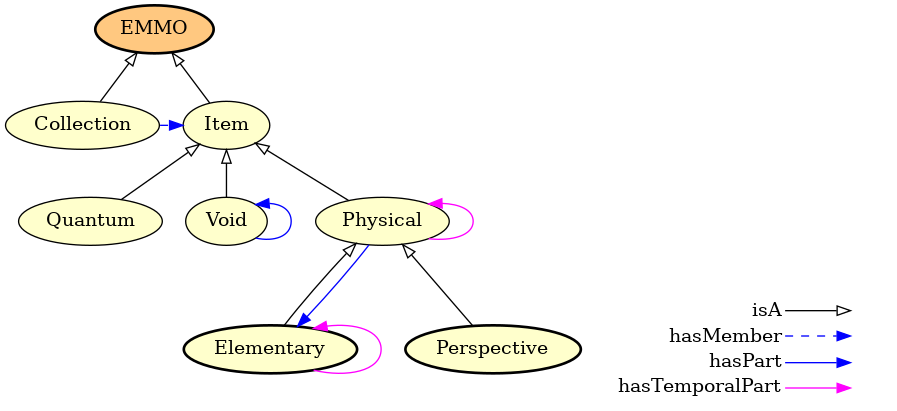

The EMMO top level.

In EMMO, the only univocally defined real world object is the *Item* individual called **Universe** that stands for the universe. Every other real world object is a composition of elementaries up to the most comprehensive object; the **Universe**. Intermediate objects are not univocally defined, but their definition is provided according to some specific philosophical perspectives. This is an expression of reductionism (i.e. objects are made of sub-objects) and epistemological pluralism (i.e. objects are always defined according to the perspective of an interpreter, or a class of interpreters).

The *Perspective* class collects the different ways to represent the objects that populate the conceptual region between the elementary and universe levels.

### Middle Level

The middle level ontologies act as roots for extending the EMMO towards specific application domains.

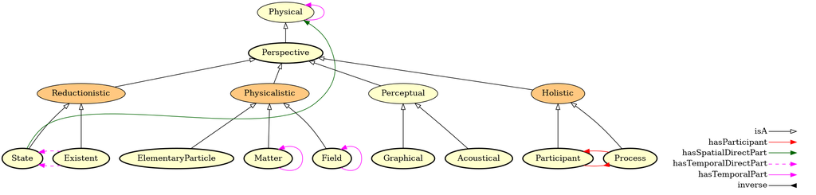

The EMMO perspectives.

The *Reductionistic* perspective class uses the fundamental non-transitive parthood relation, called direct parthood, to provide a powerful granularity description of multiscale real world objects. The EMMO can in principle represents the **Universe** with direct parthood relations as a direct rooted tree up to its elementary constituents.

The *Physicalistic* perspective class introduces the concept of real world objects that have a meaning for the under applied physics perspective.

The *Holistic* perspective class introduces the concept of real world objects that unfold in time in a way that has a meaning for the EMMO user, through the definition of the classes *Process* and *Participant*. The semiotics module introduces the concepts of semiotics and the *Semiosis* process that has a *Sign*, an *Object* and an *Interpreter* as participants. This forms the basis in EMMO to represent e.g. models, formal languages, theories, information and properties.

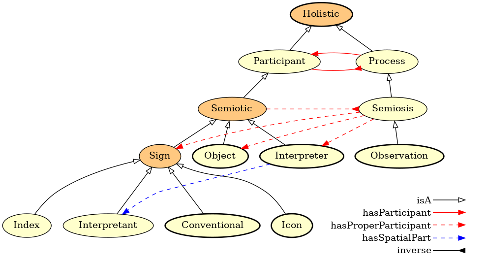

The semiotic level, showing both the taxonomy (open black arrows) and other relations as listed in the caption. The inverted arrows corresponds to inverse relations.

### EMMO relations

All EMMO relations are subrelations of the relations found in the two roots: *mereotopological* and *semiotical*. The relation hierarchy extends more vertically (i.e. more subrelations) than horizontally (i.e. less sibling relations), facilitating the categorisation and inferencing of individuals. See also the chapter EMMO Relations.

Imposing all relations to fall under mereotopology or semiotics is how the EMMO force the developers to respect its perspectives. Two entities are related only by contact or parthood (mereotopology) or by standing one for another (semiosis): no other types of relation are possible within the EMMO.

A unique feature in EMMO, is the introduction of *direct parthood*. As illustrated in the figure below, it is a mereological relation that lacks transitivity. This makes it possible to entities made of parts at different levels of granularity and to go between granularity levels in a well-defined manner. This is paramount for cross scale interoperability. Every material in EMMO is placed on a granularity level and the ontology gives information about the direct upper and direct lower level classes using the non-transitive direct parthood relations.

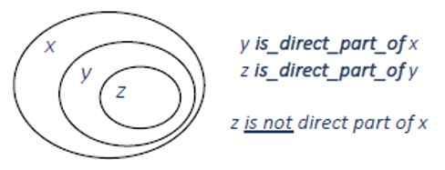

Direct parthood.

### Annotations

All entities and relations in EMMO have some attributes, called *annotations*. In some cases, only the required *International Resource Identifier* (IRI) and *relations* are provided. However, descriptive annotations, like *elucidation* and *comment*, are planned to be added for all classes and relations. Possible annotations are:

- **Elucidation** is a human readable explanation and clearification of the documented class or relation.
- **Example** clearifies the elucidation through an example. A class may have several examples, each addressing different aspects.
- **Comment** is a clearifying note complementing the definition and elucidation. A class may have several comments, each clearifying different aspects.
- **IRI** stands for *international resource identifier*. It is an identifier that uniquely identifies the class or relation. IRIs are similar to URIs, but are not restricted to the ASCII character set. In EMMO, the IRIs are now valid URLs pointing to the stable version of EMMO.
- **Relations** is a list of relations applying to the current class or relation. The relations for relations are special and will be elaborated on in the introduction to chapter [Relations]. Some of the listed relations are defined in the OWL sources, while other are inferred by the reasoner. The relations are expressed using the Manchester OWL syntax introduced in section Description logic.

# EMMO Relations

In the language of OWL, relations are called *properties*. However, since relations describe relations between classes and individuals and since properties has an other meaning in EMMO, we only call them *relations*.

[Resource Description Framework (RDF)](https://en.wikipedia.org/wiki/Resource_Description_Framework) is a W3C standard that is widely used for describing informations on the web and is one of the standards that OWL builds on. RDF expresses information in form of *subject-predicate-object* triplets. The subject and object are resources (aka items to describe) and the predicate expresses a relationship between the subject and the object.

In OWL are the subject and object classes or individuals (or data) while the predicate is a relation. An example of an relationship is the statement *dog is_a animal*. Here `dog` is the subject, `is_a` the predicate and `animal` the object.

OWL distingues between *object properties*, that link classes or individuals to classes or individuals, and *data properties* that link individuals to data values. Since EMMO only deals with classes, we will only be discussing object properties. However, in actual simulation or characterisation applications build on EMMO, datatype propertyes will be important.

The characteristics of the different properties are described by the following *property axioms*:

- `rdf:subPropertyOf` is used to define that a property is a subproperty of some other property. For instance, in the figure below showing the relation branch, we see that `active_relation` is a subproperty or `relation`. The `rdf:subPropertyOf` axioms forms a taxonomy-like tree for relations.
- `owl:equivalentProperty` states that two properties have the same property extension.
- `owl:inverseOf` axioms relate active relations to their corresponding passive relations, and vice versa. The root relation `relation` is its own inverse.
- `owl:FunctionalProperty` is a property that can have only one (unique) value y for each instance x, i.e. there cannot be two distinct values y1 and y2 such that the pairs (x,y1) and (x,y2) are both instances of this property. Both object properties and datatype properties can be declared as “functional”.
- `owl:InverseFunctionalProperty`
- `owl:TransitiveProperty` states that if a pair (x,y) is an instance of P, and the pair (y,z) is instance of P, then we can infer that the pair (x,z) is also an instance of P.
- `owl:SymmetricProperty` states that if the pair (x,y) is an instance of P, then the pair (y,x) is also an instance of P. A popular example of a symmetric property is the `siblingOf` relation.
- `rdfs:domain` specifies which classes the property applies to. Or said differently, the valid values of the *subject* in a *subject-predicate-object* triplet.
- `rdfs:range` specifies the property extension, i.e. the valid values of the *object* in a *subject-predicate-object* triplet.

## Root of EMMO relations

[figure not shown]

Top-level of the EMMO relation hierarchy.

### EMMORelation

**IRI:** [http://emmo.info/emmo/top/mereotopology#EMMO_ec2472ae_cf4a_46a5_8555_1556f5a6c3c5](http://emmo.info/emmo/top/mereotopology#emmo_ec2472ae_cf4a_46a5_8555_1556f5a6c3c5)

**Relations:**

- is_a owl:ObjectProperty
- is_a owl:SymmetricProperty
- is_a owl:TransitiveProperty
- is_a owl:topObjectProperty
- inverse_of mereotopology.EMMORelation
- domain mereotopology.EMMO
- range mereotopology.EMMO

## Mereotopological branch

[figure not shown]

Mereotopological branch.

### mereotopological

**IRI:** [http://emmo.info/emmo/top/mereotopology#EMMO_03212fd7_abfd_4828_9c8e_62c293052d4b](http://emmo.info/emmo/top/mereotopology#emmo_03212fd7_abfd_4828_9c8e_62c293052d4b)

**Comment:** Mereotopology merges mereological and topological concepts and provides relations between wholes, parts, boundaries, etc.

**Relations:**

- is_a owl:ObjectProperty
- is_a owl:SymmetricProperty
- is_a owl:TransitiveProperty
- is_a mereotopology.EMMORelation
- Inverse(mereotopology.EMMORelation)
- inverse_of mereotopology.mereotopological

### disconnected

**IRI:** [http://emmo.info/emmo/top/mereotopology#EMMO_517dfaf9_4970_41ac_81ee_d031627d2c7c](http://emmo.info/emmo/top/mereotopology#emmo_517dfaf9_4970_41ac_81ee_d031627d2c7c)

**Relations:**

- is_a owl:ObjectProperty
- is_a owl:SymmetricProperty
- is_a mereotopology.mereotopological
- Inverse(mereotopology.mereotopological)
- inverse_of mereotopology.disconnected

## Connected branch

[figure not shown]

Connected branch.

### hasContactWith

**IRI:** [http://emmo.info/emmo/top/mereotopology#EMMO_4d6504f1_c470_4ce9_b941_bbbebc9ab05d](http://emmo.info/emmo/top/mereotopology#emmo_4d6504f1_c470_4ce9_b941_bbbebc9ab05d)

**Relations:**

- is_a owl:ObjectProperty
- is_a owl:SymmetricProperty
- is_a mereotopology.connected
- Inverse(mereotopology.connected)
- inverse_of mereotopology.hasContactWith

### connected

**IRI:** [http://emmo.info/emmo/top/mereotopology#EMMO_6703954e_34c4_4a15_a9e7_f313760ae1a8](http://emmo.info/emmo/top/mereotopology#emmo_6703954e_34c4_4a15_a9e7_f313760ae1a8)

**Comment:** Causality is a topological property between connected items.

**Comment:** Items being connected means that there is a topological contact or “interaction” between them.

**Relations:**

- is_a owl:ObjectProperty
- is_a owl:SymmetricProperty
- is_a mereotopology.mereotopological
- Inverse(mereotopology.mereotopological)
- inverse_of mereotopology.connected

### encloses

**IRI:** [http://emmo.info/emmo/top/mereotopology#EMMO_8c898653_1118_4682_9bbf_6cc334d16a99](http://emmo.info/emmo/top/mereotopology#emmo_8c898653_1118_4682_9bbf_6cc334d16a99)

**Comment:** Enclosure is reflexive and transitive.

**Relations:**

- is_a owl:ObjectProperty
- is_a owl:TransitiveProperty
- is_a mereotopology.connected
- Inverse(mereotopology.connected)

### hasOverlapWith

**IRI:** [http://emmo.info/emmo/top/mereotopology#EMMO_d893d373_b579_4867_841e_1c2b31a8d2c6](http://emmo.info/emmo/top/mereotopology#emmo_d893d373_b579_4867_841e_1c2b31a8d2c6)

**Relations:**

- is_a owl:ObjectProperty
- is_a owl:SymmetricProperty
- is_a mereotopology.connected
- Inverse(mereotopology.connected)
- inverse_of mereotopology.hasOverlapWith

### overcrosses

**IRI:** [http://emmo.info/emmo/top/mereotopology#EMMO_9cb984ca_48ad_4864_b09e_50d3fff19420](http://emmo.info/emmo/top/mereotopology#emmo_9cb984ca_48ad_4864_b09e_50d3fff19420)

**Relations:**

- is_a owl:ObjectProperty
- is_a owl:SymmetricProperty
- is_a mereotopology.hasOverlapWith
- Inverse(mereotopology.hasOverlapWith)
- inverse_of mereotopology.overcrosses

## Has Part branch

[figure not shown]

Has Part branch.

### hasSpatialPart

**IRI:** [http://emmo.info/emmo/top/physical#EMMO_f68030be_94b8_4c61_a161_886468558054](http://emmo.info/emmo/top/physical#emmo_f68030be_94b8_4c61_a161_886468558054)

**Relations:**

- is_a owl:ObjectProperty
- is_a owl:TransitiveProperty
- is_a mereotopology.hasProperPart
- domain mereotopology.Item
- range mereotopology.Item

### hasProperParticipant

**IRI:** [http://emmo.info/emmo/middle/holistic#EMMO_c5aae418_1622_4d02_93c5_21159e28e6c1](http://emmo.info/emmo/middle/holistic#emmo_c5aae418_1622_4d02_93c5_21159e28e6c1)

**Relations:**

- is_a owl:ObjectProperty
- is_a holistic.hasParticipant
- is_a mereotopology.hasProperPart

### hasParticipant

**IRI:** [http://emmo.info/emmo/middle/holistic#EMMO_ae2d1a96_bfa1_409a_a7d2_03d69e8a125a](http://emmo.info/emmo/middle/holistic#emmo_ae2d1a96_bfa1_409a_a7d2_03d69e8a125a)

**Comment:** Participation is a parthood relation: you must be part (and then be connected) of the process to contribute to it.

**Comment:** Participation is not under direct parthood since a process is not strictly related to reductionism, but it’s a way to categorize temporal regions by the interpreters.

**Relations:**

- is_a owl:ObjectProperty
- is_a mereotopology.hasPart
- domain holistic.Process
- range holistic.Participant

### hasPart

**IRI:** [http://emmo.info/emmo/top/mereotopology#EMMO_17e27c22_37e1_468c_9dd7_95e137f73e7f](http://emmo.info/emmo/top/mereotopology#emmo_17e27c22_37e1_468c_9dd7_95e137f73e7f)

**Relations:**

- is_a owl:ObjectProperty
- is_a owl:TransitiveProperty
- is_a mereotopology.encloses
- is_a mereotopology.hasOverlapWith
- Inverse(mereotopology.hasOverlapWith)

### hasMember

**IRI:** [http://emmo.info/emmo/top/mereotopology#EMMO_6b7276a4_4b9d_440a_b577_0277539c0fc4](http://emmo.info/emmo/top/mereotopology#emmo_6b7276a4_4b9d_440a_b577_0277539c0fc4)

**Relations:**

- is_a owl:ObjectProperty
- is_a owl:AsymmetricProperty
- is_a owl:IrreflexiveProperty
- is_a mereotopology.hasProperPart
- domain mereotopology.Collection
- range mereotopology.Item

### hasProperPart

**IRI:** [http://emmo.info/emmo/top/mereotopology#EMMO_9380ab64_0363_4804_b13f_3a8a94119a76](http://emmo.info/emmo/top/mereotopology#emmo_9380ab64_0363_4804_b13f_3a8a94119a76)

**Relations:**

- is_a owl:ObjectProperty
- is_a owl:TransitiveProperty
- is_a mereotopology.hasPart

### hasSpatialDirectPart

**IRI:** [http://emmo.info/emmo/middle/reductionistic#EMMO_b2282816_b7a3_44c6_b2cb_3feff1ceb7fe](http://emmo.info/emmo/middle/reductionistic#emmo_b2282816_b7a3_44c6_b2cb_3feff1ceb7fe)

**Relations:**

- is_a owl:ObjectProperty
- is_a owl:InverseFunctionalProperty
- is_a owl:AsymmetricProperty
- is_a owl:IrreflexiveProperty
- is_a physical.hasSpatialPart
- domain reductionistic.State

### hasReferenceUnit

**IRI:** [http://emmo.info/emmo/middle/metrology#EMMO_67fc0a36_8dcb_4ffa_9a43_31074efa3296](http://emmo.info/emmo/middle/metrology#emmo_67fc0a36_8dcb_4ffa_9a43_31074efa3296)

**Comment:** Relates the physical quantity to its unit through spatial direct parthood.

**Versioninfo:** In EMMO version 1.0.0-alpha2, physical quantities used the hasReferenceUnit object property to relate them to their units via physical dimensionality. This was simplified in 1.0.0-alpha3 in order to make reasoning faster.

The restriction (e.g. for the physical quantity Length)

```
Length hasReferenceUnit only (hasPhysicsDimension only LengthDimension)
```

was in 1.0.0-alpha3 changed to

```
Length hasPhysicsDimension some LengthDimension
```

Likewise were the universal restrictions on the corresponding unit changed to excistential. E.g.

```
Metre hasPhysicsDimension only LengthDimension
```

was changed to

```
Metre hasPhysicsDimension some LengthDimension
```

The label of this class was also changed from PhysicsDimension to PhysicalDimension.

**Relations:**

- is_a owl:ObjectProperty
- is_a owl:InverseFunctionalProperty
- is_a owl:AsymmetricProperty
- is_a owl:IrreflexiveProperty
- is_a reductionistic.hasSpatialDirectPart
- domain metrology.Quantity
- range metrology.ReferenceUnit

### hasQuantityValue

**IRI:** [http://emmo.info/emmo/middle/metrology#EMMO_8ef3cd6d_ae58_4a8d_9fc0_ad8f49015cd0](http://emmo.info/emmo/middle/metrology#emmo_8ef3cd6d_ae58_4a8d_9fc0_ad8f49015cd0)

**Relations:**

- is_a owl:ObjectProperty
- is_a owl:InverseFunctionalProperty
- is_a owl:AsymmetricProperty
- is_a owl:IrreflexiveProperty
- is_a reductionistic.hasSpatialDirectPart
- domain metrology.Quantity
- range math.Numerical

### hasTemporalDirectPart

**IRI:** [http://emmo.info/emmo/middle/reductionistic#EMMO_65a2c5b8_e4d8_4a51_b2f8_e55effc0547d](http://emmo.info/emmo/middle/reductionistic#emmo_65a2c5b8_e4d8_4a51_b2f8_e55effc0547d)

**Relations:**

- is_a owl:ObjectProperty
- is_a owl:InverseFunctionalProperty
- is_a owl:AsymmetricProperty
- is_a owl:IrreflexiveProperty
- is_a physical.hasTemporalPart
- domain reductionistic.Existent
- range reductionistic.State

### hasSpatioTemporalPart

**IRI:** [http://emmo.info/emmo/top/physical#EMMO_6e046dd0_9634_4013_b2b1_9cc468087c83](http://emmo.info/emmo/top/physical#emmo_6e046dd0_9634_4013_b2b1_9cc468087c83)

**Relations:**

- is_a owl:ObjectProperty
- is_a owl:TransitiveProperty
- is_a mereotopology.hasProperPart
- domain mereotopology.Item
- range mereotopology.Item

### hasTemporalPart

**IRI:** [http://emmo.info/emmo/top/physical#EMMO_7afbed84_7593_4a23_bd88_9d9c6b04e8f6](http://emmo.info/emmo/top/physical#emmo_7afbed84_7593_4a23_bd88_9d9c6b04e8f6)

**Relations:**

- is_a owl:ObjectProperty
- is_a owl:TransitiveProperty
- is_a mereotopology.hasProperPart
- domain mereotopology.Item
- range mereotopology.Item

### hasSpatioTemporalDirectPart

**IRI:** [http://emmo.info/emmo/middle/reductionistic#EMMO_663859e5_add3_4c9e_96fb_c99399de278d](http://emmo.info/emmo/middle/reductionistic#emmo_663859e5_add3_4c9e_96fb_c99399de278d)

**Relations:**

- is_a owl:ObjectProperty
- is_a owl:InverseFunctionalProperty
- is_a owl:AsymmetricProperty
- is_a owl:IrreflexiveProperty
- is_a physical.hasSpatioTemporalPart

## Semiotical branch

[figure not shown]

Semiotical branch.

### hasModel

**IRI:** [http://emmo.info/emmo/middle/models#EMMO_24c71baf_6db6_48b9_86c8_8c70cf36db0c](http://emmo.info/emmo/middle/models#emmo_24c71baf_6db6_48b9_86c8_8c70cf36db0c)

**Relations:**

- is_a owl:ObjectProperty
- is_a semiotics.hasIcon

### hasVariable

**IRI:** [http://emmo.info/emmo/middle/math#EMMO_3446e167_c576_49d6_846c_215bb8878a55](http://emmo.info/emmo/middle/math#emmo_3446e167_c576_49d6_846c_215bb8878a55)

**Relations:**

- is_a owl:ObjectProperty
- is_a semiotics.hasConvention
- domain math.Mathematical
- range math.Variable

### hasConvention

**IRI:** [http://emmo.info/emmo/middle/semiotics#EMMO_eb3518bf_f799_4f9e_8c3e_ce59af11453b](http://emmo.info/emmo/middle/semiotics#emmo_eb3518bf_f799_4f9e_8c3e_ce59af11453b)

**Relations:**

- is_a owl:ObjectProperty
- is_a semiotics.hasSign
- range semiotics.Conventional

### hasSign

**IRI:** [http://emmo.info/emmo/middle/semiotics#EMMO_60577dea_9019_4537_ac41_80b0fb563d41](http://emmo.info/emmo/middle/semiotics#emmo_60577dea_9019_4537_ac41_80b0fb563d41)

**Relations:**

- is_a owl:ObjectProperty
- is_a semiotics.semiotical
- domain semiotics.Object
- range semiotics.Sign

### hasInterpretant

**IRI:** [http://emmo.info/emmo/middle/semiotics#EMMO_7fb7fe7e_bdf9_4eeb_adad_e384dd5285c6](http://emmo.info/emmo/middle/semiotics#emmo_7fb7fe7e_bdf9_4eeb_adad_e384dd5285c6)

**Relations:**

- is_a owl:ObjectProperty
- is_a semiotics.hasSign
- range semiotics.Interpretant

### hasProperty

**IRI:** [http://emmo.info/emmo/middle/properties#EMMO_e1097637_70d2_4895_973f_2396f04fa204](http://emmo.info/emmo/middle/properties#emmo_e1097637_70d2_4895_973f_2396f04fa204)

**Relations:**

- is_a owl:ObjectProperty
- is_a semiotics.hasConvention
- domain semiotics.Object
- range properties.Property

### hasPhysicalDimension

**IRI:** [http://emmo.info/emmo/middle/metrology#EMMO_bed1d005_b04e_4a90_94cf_02bc678a8569](http://emmo.info/emmo/middle/metrology#emmo_bed1d005_b04e_4a90_94cf_02bc678a8569)

**Relations:**

- is_a owl:ObjectProperty
- is_a properties.hasProperty
- range metrology.PhysicalDimension

### hasIcon

**IRI:** [http://emmo.info/emmo/middle/semiotics#EMMO_39c3815d_8cae_4c8f_b2ff_eeba24bec455](http://emmo.info/emmo/middle/semiotics#emmo_39c3815d_8cae_4c8f_b2ff_eeba24bec455)

**Relations:**

- is_a owl:ObjectProperty
- is_a semiotics.hasSign
- range semiotics.Icon

### hasIndex

**IRI:** [http://emmo.info/emmo/middle/semiotics#EMMO_297999d6_c9e4_4262_9536_bd524d1c6e21](http://emmo.info/emmo/middle/semiotics#emmo_297999d6_c9e4_4262_9536_bd524d1c6e21)

**Relations:**

- is_a owl:ObjectProperty
- is_a semiotics.hasSign
- range semiotics.Index

### semiotical

**IRI:** [http://emmo.info/emmo/middle/semiotics#EMMO_2337e25c_3c60_43fc_a8f9_b11a3f974291](http://emmo.info/emmo/middle/semiotics#emmo_2337e25c_3c60_43fc_a8f9_b11a3f974291)

**Relations:**

- is_a owl:ObjectProperty
- is_a mereotopology.EMMORelation
- Inverse(mereotopology.EMMORelation)

# EMMO Classes

*emmo* is a class representing the collection of all the individuals (signs) that are used in the ontology. Individuals are declared by the EMMO users when they want to apply the EMMO to represent the world.

## EMMO branch

[figure not shown]

EMMO branch.

The root of all classes used to represent the world. It has two children; *collection* and *item*.

*collection* is the class representing the collection of all the individuals (signs) that represents a collection of non-connected real world objects.

*item* Is the class that collects all the individuals that are members of a set (it’s the most comprehensive set individual). It is the branch of mereotopology.

### EMMO

**IRI:** [http://emmo.info/emmo/top/mereotopology#EMMO_802d3e92_8770_4f98_a289_ccaaab7fdddf](http://emmo.info/emmo/top/mereotopology#emmo_802d3e92_8770_4f98_a289_ccaaab7fdddf)

**Elucidation:** The class representing the collection of all the individuals declared in this ontology standing for real world objects.

**Comment:** ‘EMMO’ is the disjoint union of ‘Item’ and ‘Collection’ (covering axiom).

The union implies that ‘EMMO’ individuals can only be ‘Item’ individuals (standing for self-connected real world objects) or ‘Collection’ individuals (standing for a collection of disconnected items).

Disjointness means that a ‘Collection’ individual cannot be an ‘Item’ individual and viceversa, representing the fact that a real world object cannot be self-connected and non-self connected at the same time.

**Comment:** For the EMMO ontologist the whole universe is represented as a 4D path-connected topological manifold (i.e. the spacetime).

A real world object is then a 4D topological sub-region of the universe.

A universe sub-region is isolated and defined as a real world object by the ontologist. Then, through a semiotic process that occurs at meta-ontological level (i.e. outside the ontology). an EMMO ontology entity (e.g. an OWL individual) is assigned to represent that real world object.

The fundamental distinction between real world objects, upon which the EMMO is based, is self-connectedness: a real world object can be self-connected xor not self-connected.

**Comment:** In the EMMO we will refer to the universe as a Minkowski space, restricting the ontology to special relativity only. However, exension to general relativity, will adding more complexity, should not change the overall approach.

**Comment:** Mereotopology is the fundamental logical representation used by the EMMO ontologist to characterize the universe and to provide the definitions to connect real world objects to the EMMO concepts.

Parthood relations do not change dimensionality of the real world object referred by an ‘EMMO’ individual, i.e. every part of a real world object always retains its 4D dimensionality.

The smallest part of a real world object (i.e. a part that has no proper parts) is referred in the EMMO by a ‘Quantum’ individual.

It follows that, for the EMMO, real world objects of dimensionality lower than 4D (e.g. surfaces, lines) do not exist.

**Relations:**

- is_a owl:Thing
- equivalent_to mereotopology.hasPart some mereotopology.Quantum
- equivalent_to Inverse(mereotopology.hasPart) value mereotopology.Universe
- disjoint_union_of mereotopology.Collection, mereotopology.Item

### Item

**IRI:** [http://emmo.info/emmo/top/mereotopology#EMMO_eb3a768e_d53e_4be9_a23b_0714833c36de](http://emmo.info/emmo/top/mereotopology#emmo_eb3a768e_d53e_4be9_a23b_0714833c36de)

**Comment:** A real world object is self-connected if any two parts that make up the whole are connected to each other (here the concept of connection is primitive).

Alternatively, using the primitive path-connectivity concept we can define a self-connected real world object as an object for which each couple of points is path-connected.

**Comment:** An ‘Item’ individual stands for a real world self-connected object which can be represented as a whole made of connected parts (e.g. a car made of components).

In the EMMO, connectivity is the topological foundation of causality.

All physical systems, i.e. systems whose behaviour is explained by physics laws, are represented only by ‘Item’-s.

Members of a ‘Collection’ lack of causality connection, i.e. they do not constitute a physical system as a whole.

**Comment:** From Latin item, “likewise, just so, moreover”.

**Relations:**

- is_a mereotopology.EMMO
- disjoint_union_of physical.Void, physical.Physical

### Void

**IRI:** [http://emmo.info/emmo/top/physical#EMMO_29072ec4_ffcb_42fb_bdc7_26f05a2e9873](http://emmo.info/emmo/top/physical#emmo_29072ec4_ffcb_42fb_bdc7_26f05a2e9873)

**Elucidation:** A ‘Item’ that has no ‘Physical’ parts.

**Comment:** From Latin vacuus, “empty”.

**Comment:** The void concept is paramount for the representation of physical systems according to quantum theory.

**Relations:**

- is_a mereotopology.Item
- mereotopology.hasPart only physical.Void

### Physical

**IRI:** [http://emmo.info/emmo/top/physical#EMMO_c5ddfdba_c074_4aa4_ad6b_1ac4942d300d](http://emmo.info/emmo/top/physical#emmo_c5ddfdba_c074_4aa4_ad6b_1ac4942d300d)

**Elucidation:** A ‘Item’ that has part some ‘Elementary’ and whose temporal proper parts are only ‘Physical’-s (i.e. it can be perceived without interruptions in time).

**Comment:** A ‘Physical’ is the class that contains all the individuals that stand for real world objects that interact physically with the ontologist, i.e. physical objects.

A physical object must be perceived through physical interaction by the ontologist. Then the ontologist can declare an individual standing for the physical object just perceived.

Perception is a subcategory of physical interactions. It is an interaction that stimulate a representation of the physical object within the ontologist (the agent).

**Comment:** A ‘Physical’ must include at least an ‘Elementary’ part, and can include ‘Void’ parts.

A ‘Physical’ may include as part also the ‘Void’ surrounding or enclosed by its ‘Physical’ sub parts.

There are no particular criteria for ‘Physical’-s structure, except that is made of some ‘Elementary’-s as proper parts and not only ‘Void’.

This is done in order to take into account the quantum nature of physical systems, in which the actual position of sub-components (e.g. electrons in an atom) is not known except for its probability distribution function (according to the Copenhagen interpretation.)

e.g. a real world object that has spatial parts an atom and a cubic light year of void, extending for some time, can be a physical object.

**Comment:** A ‘Physical’ with dimensions other than 4D cannot exist, following the restriction of the parent ‘EMMO’ class.

It follows from the fact that perception is always unfolding in time.

e.g. you always have an aperture time when you take a picture or measure a property. Instantaneous perceptions are idealizations (abstractions) or a very small time measurement.

**Comment:** From Latin physica “study of nature” (and Ancient Greek φυσικός, “natural”).

Here the word relates to things perceived through the senses as opposed to the mind; tangible or concrete.

**Comment:** In the EMMO there are no relations such as occupiesSpace, since ‘Physical’-s are themselves the 4D regions.

**Comment:** The EMMO can be used to represent real world entities as ‘Physical’-s that are easy to connect to classical or quantum mechanical based models.

Classical mechanics poses no representational issues, for the EMMO: the 4D representation of ‘Physical’-s is consistent with classical physics systems.

However, the representation of ‘Physical’-s that are typically analized through quantum mechanics (e.g. molecules, atoms, clusters), is not straightforward.

1. De Broglie - Bohm interpretation The most simple approach is to rely on Bohmian mechanics, in which each particle is supposed to exists in a specific position between measurements (hidden variables approach), while its trajectory is calculated using a Guiding Equation based on a quantum field calculated with the Schroedinger Equation.

While this approach is really easy to implement in an ontology, since each entity has its own well defined 4D region, its mathematical representation failed to receive large consensus due to the difficulties to include relativistic effects, to be extended to subnuclear scale and the strong non-locality assumtpion of the quantum field.

Nevertheless, the Bohmian mechanics is a numerical approach that is used in electronic models to reduce the computational effort of the solution of Schroedinger Equation.

In practice, an EMMO user can declare a ‘physical’ individual that stand for the whole quantum system to be described, and at the same time all sub-parts individuals can be declared, having them a well defined position in time, according to De Broglie - Bohm interpretation. The Hamiltonian can be calculated by considering the sub-part individuals.

‘physical’-s are then made of ‘physical’ parts and ‘void’ parts that stand for the space between ‘physical’-s (e.g. the void between electrons and nucleus in an atom).

2. Copenhagen interpretation In this interpretation the properties (e.g. energy level, position, spin) of a particle are not defined in the interval between two measurements and the quantum system is entangled (i.e. properties of particles in the sysyem are correlated) and described by a global wavefunction obtained solving the Schroedinger Equation.

Upon measurement, the wavefunction collapses to a combination of close eigenstates that provide information about bservables of the system components (e.g. position, energy).

The EMMO can be used to represent ‘physical’-s that can be related to Copenhagen based models. In practice, the user should follow these steps:

1. define the quantum system as a ‘physical’ individual (e.g. an H2 molecule) under a specific class (e.g. ‘h2_molecule’). This individual is the whole.
2. define the axioms of the class that describe how many sub-parts are expected for the whole and their class types (e.g. ‘h2_molecule’ has axioms ‘has_proper_part exactly 2 electron’ and ’has_proper_part exactly 2 nucleus)
3. the user can now connect the whole to a Schroedinger equation based model whose Hamiltonian is calculated trough the information coming only from the axioms. No individuals are declared for the subparts!
4. a measurement done on the quantum system that provides information on the sub-part observables is interpreted as wavefunction collapse and leads to the end of the whole and the declaration of the sub-parts individuals which can be themselves other quantum systems

e.g. if the outer electron of the H2 molecule interacts with another entity defining its state, then the whole that stands for the entangled H2 molecule becomes a ‘physical’ made of an electron individual, a quantum system made of one electron and two nuclei and the void between them.

e.g. in the Born-Oppenheimer approximation the user represent the atom by un-entangling nucleus and electronic cloud. The un-entanglement comes in the form of declaration of individual as parts.

e.g. the double slit experiment can be represent in the EMMO as: a) before the slit: a ‘physical’ that extend in space and has parts ‘electron’ and ‘void’, called ‘single_electron_wave_function’. ‘electron’ and ‘void’ are only in the axioms and not decalred individuals. b) during slit passage: a ‘physical’ made of one declared individual, the ‘electron’. c) after the slit: again ‘single_electron_wave_function’ d) upon collision with the detector: ‘physical’ made of one declared individual, the ‘electron’.

**Comment:** The purpose of the ‘Physical’ branch is to provide a representation of the real world objects, while the models used to name, explain or predict the behaviour of the real world objects lay under the ‘Semiotic’ branch.

More than one semiotic representation can be connected to the same ‘Physical’.

e.g. Navier-Stokes or Euler equation applied to the same fluid are an example of mathematical model used to represent a physical object for some specific interpreter.

**Relations:**

- is_a mereotopology.Item
- mereotopology.hasPart some physical.Elementary
- physical.hasTemporalPart only physical.Physical

**Individuals:**

- mereotopology.Universe

### Collection

**IRI:** [http://emmo.info/emmo/top/mereotopology#EMMO_2d2ecd97_067f_4d0e_950c_d746b7700a31](http://emmo.info/emmo/top/mereotopology#emmo_2d2ecd97_067f_4d0e_950c_d746b7700a31)

**Elucidation:** The class of all individuals that stand for a real world not self-connected object.

**Comment:** A ‘Collection’ individual stands for a non-self-connected real world object.

A ‘Collection’ individual is related to each ‘Item’ individuals of the collection (i.e. the members) through the membership relation.

An ‘Item’ individual stands for a real world self-connected object which can be represented as a whole made of connected parts (e.g. a car made of components).

**Comment:** Formally, ‘Collection’ is axiomatized as the class of individuals that hasMember some ‘Item’.

A ‘Collection’ cannot have as member another ‘Collection’.

**Comment:** From Latin collectio, from colligere ‘gather together’.

**Comment:** e.g. the collection of users of a particular software, the collection of atoms that have been part of that just dissociated molecule, or even the collection of atoms that are part of a molecule considered as single individual non-connected objects and not as a mereotopological self-connected fusion.

**Relations:**

- is_a mereotopology.EMMO
- mereotopology.hasMember some mereotopology.Item

### Quantum

**IRI:** [http://emmo.info/emmo/top/mereotopology#EMMO_3f9ae00e_810c_4518_aec2_7200e424cf68](http://emmo.info/emmo/top/mereotopology#emmo_3f9ae00e_810c_4518_aec2_7200e424cf68)

**Elucidation:** The class of ‘EMMO’ individuals that stand for real world objects that can’t be further divided in time nor in space.

**Example:** For a physics based ontology the ‘Quantum’ can stand for the smallest identifiable portion of spacetime defined by the Planck limit in length (1.616e-35 m) and time (5.39e-44 s).

However, the quantum mereotopology approach is not restricted only to physics. For example, in a manpower management ontology, a ‘Quantum’ can stand for an hour (time) of a worker (space) activity.

**Comment:** A ‘Quantum’ is the most fundamental subclass of ‘Item’, since its individuals stand for the smallest possible self-connected 4D real world objects.

The quantum concept recalls the fact that there is lower epistemological limit to our knowledge of the universe, related to the uncertainity principle.

**Comment:** A ‘Quantum’ stands for a 4D real world object.

**Comment:** A quantum is the EMMO mereological 4D a-tomic entity.

To avoid confusion with the concept of atom coming from physics, we will use the expression quantum mereology, instead of a-tomistic mereology.

**Comment:** From Latin quantum (plural quanta) “as much as, so much as;”, introduced in physics directly from Latin by Max Planck, 1900.

**Relations:**

- is_a mereotopology.Item
- is_a mereotopology.EMMO
- mereotopology.hasProperPart only owl:Nothing

## Elementary branch

[figure not shown]

Elementary branch.

### Elementary

**IRI:** [http://emmo.info/emmo/top/physical#EMMO_0f795e3e_c602_4577_9a43_d5a231aa1360](http://emmo.info/emmo/top/physical#emmo_0f795e3e_c602_4577_9a43_d5a231aa1360)

**Elucidation:** The basic constituent of ‘item’-s that can be proper partitioned only in time up to quantum level.

**Comment:** According to mereology, this should be call ‘a-tomistic’ in the strict etimological sense of the word (from greek, a-tomos: un-divisible).

Mereology based on such items is called atomistic mereology.

However, in order not to confuse the lexicon between mereology and physics (in which an atom is a divisible physical entity) we prefer to call it ‘elementary’, recalling the concept of elementary particle coming from the standard particles model.

**Comment:** From Latin elementārius (“elementary”), from elementum (“one of the four elements of antiquity; fundamentals”)

**Comment:** While a ‘Quantum’ is a-tomistic in time and space, an ‘elementary’ is a-tomistic only in space, recalling the concept of elementary particle.

**Relations:**

- is_a physical.Physical
- physical.hasTemporalPart only physical.Elementary
- physical.hasSpatialPart only owl:Nothing

## Perspective branch

[figure not shown]

Perspective branch.

### Perspective

**IRI:** [http://emmo.info/emmo/top#EMMO_49267eba_5548_4163_8f36_518d65b583f9](http://emmo.info/emmo/top#emmo_49267eba_5548_4163_8f36_518d65b583f9)

**Elucidation:** The class of individuals that stand for real world objects according to a specific representational perspective.

**Comment:** This class is the practical implementation of the EMMO pluralistic approach for which the only objective categorization is provided by the Universe individual and all the Quantum individuals.

Between these two extremes, there are several subjective ways to categorize real world objects, each one provide under a ‘Perspective’ subclass.

**Relations:**

- is_a physical.Physical

## Holistic branch

[figure not shown]

Holistic branch.

### Participant

**IRI:** [http://emmo.info/emmo/middle/holistic#EMMO_49804605_c0fe_4538_abda_f70ba1dc8a5d](http://emmo.info/emmo/middle/holistic#emmo_49804605_c0fe_4538_abda_f70ba1dc8a5d)

**Elucidation:** A portion of a ‘Process’ that participates to the process with a specific role.

**Comment:** In the EMMO the relation of participation to a process falls under mereotopology.

Since topological connection means causality, then the only way for a real world object to participate to a process is to be a part of it.

**Relations:**

- is_a holistic.Holistic
- is_a physical.Physical
- Inverse(holistic.hasParticipant) some holistic.Process

### Holistic

**IRI:** [http://emmo.info/emmo/middle/holistic#EMMO_0277f24a_ea7f_4917_81b7_fb0406c8fc62](http://emmo.info/emmo/middle/holistic#emmo_0277f24a_ea7f_4917_81b7_fb0406c8fc62)

**Elucidation:** A union of classes that categorize physicals under a holistic perspective: the interest is on the whole 4D object (process) and the role of its 4D parts (participants) without going further into specifying the spatial hierarchy or the temporal position of each part.

**Comment:** An holistic perspective considers each part of the whole as equally important, without the need of a granularity hierarchy (in time or space).

A molecule of a body can have role in the body evolution, without caring if its part of a specific organ and without specifying the time interval in which this role occurred.

This class allows the picking of parts without necessarily going trough a rigid hierarchy of spatial compositions (e.g. body -> organ -> cell -> molecule) or temporal composition.

**Comment:** Holism (from Greek ὅλος holos “all, whole, entire”)

**Relations:**

- is_a top.Perspective
- equivalent_to holistic.Process or holistic.Participant

### Device

**IRI:** [http://emmo.info/emmo/middle/manufacturing#EMMO_494b372c_cfdf_47d3_a4de_5e037c540de8](http://emmo.info/emmo/middle/manufacturing#emmo_494b372c_cfdf_47d3_a4de_5e037c540de8)

**Elucidation:** An engineered object which is instrumental for reaching a particular purpose through its characteristic functioning process, with particular reference to mechanical or electronic equipment.

**Comment:** From Old French “deviser”, meaning: arrange, plan, contrive.

Literally “dispose in portions,” from Vulgar Latin “divisare”, frequentative of Latin dividere, meaning “to divide”

**Relations:**

- is_a manufacturing.Engineered
- Inverse(holistic.hasProperParticipant) some manufacturing.DiscreteManufacturing

### EngineeredMaterial

**IRI:** [http://emmo.info/emmo/middle/manufacturing#EMMO_ec7464a9_d99d_45f8_965b_4e9230ea8356](http://emmo.info/emmo/middle/manufacturing#emmo_ec7464a9_d99d_45f8_965b_4e9230ea8356)

**Comment:** A material that is synthesized within a manufacturing process.

**Relations:**

- is_a manufacturing.Engineered
- is_a physicalistic.Material
- Inverse(holistic.hasProperParticipant) some manufacturing.ContinuousManufacturing

### Engineered

**IRI:** [http://emmo.info/emmo/middle/manufacturing#EMMO_86ca9b93_1183_4b65_81b8_c0fcd3bba5ad](http://emmo.info/emmo/middle/manufacturing#emmo_86ca9b93_1183_4b65_81b8_c0fcd3bba5ad)

**Elucidation:** A ‘physical’ that stands for a real world object that has been designed and manufactured for a particular purpose.

**Example:** Car, tire, composite material.

**Comment:** The ‘Engineered’ branch represents real world objects that show some level of complexity/heterogeneity in their composition, and are made for a specific use.

**Relations:**

- is_a holistic.Participant
- Inverse(holistic.hasProperParticipant) some manufacturing.Manufacturing

## Semiotic branch

[figure not shown]

Semiotic branch.

### Semiotic

**IRI:** [http://emmo.info/emmo/middle/semiotics#EMMO_b803f122_4acb_4064_9d71_c1e5fd091fc9](http://emmo.info/emmo/middle/semiotics#emmo_b803f122_4acb_4064_9d71_c1e5fd091fc9)

**Elucidation:** The class of individuals that stands for semiotic objects, i.e. objects that take part on a semiotic process.

**Comment:** Semiotic subclasse are defined using Peirce’s semiotic theory.

“Namely, a sign is something, A, which brings something, B, its interpretant sign determined or created by it, into the same sort of correspondence with something, C, its object, as that in which itself stands to C.” (Peirce 1902, NEM 4, 20–21).

The triadic elements: - ‘sign’: the sign A (e.g. a name) - ‘interpretant’: the sign B as the effects of the sign A on the interpreter (e.g. the mental concept of what a name means) - ‘object’: the object C (e.g. the entity to which the sign A and B refer to)

This class includes also the ‘interpeter’ i.e. the entity that connects the ‘sign’ to the ‘object’

**Relations:**

- is_a holistic.Participant
- Inverse(holistic.hasProperParticipant) some semiotics.Semiosis
- equivalent_to semiotics.Interpreter or semiotics.Object or semiotics.Sign

## Sign branch

[figure not shown]

Sign branch.

### ArcSecond

**IRI:** [http://emmo.info/emmo/middle/units-extension#EMMO_6a4547ab_3abb_430d_b81b_ce32d47729f5](http://emmo.info/emmo/middle/units-extension#emmo_6a4547ab_3abb_430d_b81b_ce32d47729f5)

**Definition:** Measure of plane angle defined as 1/3600 or a degree.

**Altlabel:** SecondOfArc

**Qudtentry:** [http://qudt.org/vocab/unit/ARCSEC](http://qudt.org/vocab/unit/arcsec)

**Relations:**

- is_a units-extension.SIAcceptedSpecialUnit
- is_a metrology.OffSystemUnit
- metrology.hasPhysicalDimension some metrology.DimensionOne
- perceptual.hasSymbolData value “″”

### Index

**IRI:** [http://emmo.info/emmo/middle/semiotics#EMMO_0cd58641_824c_4851_907f_f4c3be76630c](http://emmo.info/emmo/middle/semiotics#emmo_0cd58641_824c_4851_907f_f4c3be76630c)

**Elucidation:** A ‘Sign’ that stands for an ‘Object’ due to causal continguity.

**Example:** Smoke stands for a combustion process (a fire). My facial expression stands for my emotional status.

**Relations:**

- is_a semiotics.Sign

### SIAcceptedSpecialUnit

**IRI:** [http://emmo.info/emmo/middle/units-extension#EMMO_6795a4b8_ffd0_4588_a581_a9413fe49cac](http://emmo.info/emmo/middle/units-extension#emmo_6795a4b8_ffd0_4588_a581_a9413fe49cac)

**Elucidation:** Non-SI units mentioned in the SI.

**Comment:** This is a list of units that are not defined as part of the International System of Units (SI), but are otherwise mentioned in the SI brouchure, because either the General Conference on Weights and Measures (CGPM) accepts their use as being multiples or submultiples of SI-units, they have important contemporary application worldwide, or are otherwise commonly encountered worldwide.

**Wikipediaentry:** [https://en.wikipedia.org/wiki/Non-SI_units_mentioned_in_the_SI](https://en.wikipedia.org/wiki/non-si_units_mentioned_in_the_si)

**Relations:**

- is_a metrology.SpecialUnit
- is_a metrology.OffSystemUnit
- disjoint_union_of units-extension.Dalton, units-extension.AstronomicalUnit, units-extension.ArcMinute, units-extension.Hour, units-extension.Day, units-extension.ArcSecond, units-extension.Bel, units-extension.Litre, units-extension.Neper, units-extension.Degree, units-extension.Minute, units-extension.Hectare, units-extension.ElectronVolt, units-extension.Tonne

### Day

**IRI:** [http://emmo.info/emmo/middle/units-extension#EMMO_28ef05a7_ecc1_4df6_8116_c53251fbd4a8](http://emmo.info/emmo/middle/units-extension#emmo_28ef05a7_ecc1_4df6_8116_c53251fbd4a8)

**Definition:** A measure of time defined as 86 400 seconds.

**Dbpediaentry:** [http://dbpedia.org/page/Day](http://dbpedia.org/page/day)

**Iupacentry:** [https://doi.org/10.1351/goldbook.D01527](https://doi.org/10.1351/goldbook.d01527)

**Qudtentry:** [http://qudt.org/vocab/unit/DAY](http://qudt.org/vocab/unit/day)

**Relations:**

- is_a units-extension.SIAcceptedSpecialUnit
- is_a metrology.OffSystemUnit
- metrology.hasPhysicalDimension some isq.TimeDimension
- perceptual.hasSymbolData value “d”

### Hour

**IRI:** [http://emmo.info/emmo/middle/units-extension#EMMO_21ef2ed6_c086_4d24_8a75_980d2bcc9282](http://emmo.info/emmo/middle/units-extension#emmo_21ef2ed6_c086_4d24_8a75_980d2bcc9282)

**Definition:** Measure of time defined as 3600 seconds.

**Iupacentry:** [https://doi.org/10.1351/goldbook.H02866](https://doi.org/10.1351/goldbook.h02866)

**Qudtentry:** [http://qudt.org/vocab/unit/HR](http://qudt.org/vocab/unit/hr)

**Relations:**

- is_a units-extension.SIAcceptedSpecialUnit
- is_a metrology.OffSystemUnit
- metrology.hasPhysicalDimension some isq.TimeDimension
- perceptual.hasSymbolData value “h”

### ArcMinute

**IRI:** [http://emmo.info/emmo/middle/units-extension#EMMO_1e0b665d_db6c_4752_a6d4_262d3a8dbb46](http://emmo.info/emmo/middle/units-extension#emmo_1e0b665d_db6c_4752_a6d4_262d3a8dbb46)

**Definition:** Measure of plane angle defined as 1/60 or a degree.

**Altlabel:** MinuteOfArc

**Qudtentry:** [http://qudt.org/vocab/unit/ARCMIN](http://qudt.org/vocab/unit/arcmin)

**Relations:**

- is_a units-extension.SIAcceptedSpecialUnit
- is_a metrology.OffSystemUnit
- metrology.hasPhysicalDimension some metrology.DimensionOne
- perceptual.hasSymbolData value “′”

### AstronomicalUnit

**IRI:** [http://emmo.info/emmo/middle/units-extension#EMMO_053648ea_3c0a_468c_89cb_eb009239323a](http://emmo.info/emmo/middle/units-extension#emmo_053648ea_3c0a_468c_89cb_eb009239323a)

**Definition:** One astronomical unit is defined as exactly 149597870700 m, which is roughly the distance from earth to sun.

**Dbpediaentry:** [http://dbpedia.org/page/Astronomical_unit](http://dbpedia.org/page/astronomical_unit)

**Qudtentry:** [http://qudt.org/vocab/unit/PARSEC](http://qudt.org/vocab/unit/parsec)

**Wikipediaentry:** [https://en.wikipedia.org/wiki/Astronomical_unit](https://en.wikipedia.org/wiki/astronomical_unit)

**Relations:**

- is_a units-extension.SIAcceptedSpecialUnit
- is_a metrology.OffSystemUnit
- metrology.hasPhysicalDimension some isq.LengthDimension
- perceptual.hasSymbolData value “au”

### Minute

**IRI:** [http://emmo.info/emmo/middle/units-extension#EMMO_cabb20f0_05c7_448f_9485_e129725f15a4](http://emmo.info/emmo/middle/units-extension#emmo_cabb20f0_05c7_448f_9485_e129725f15a4)

**Definition:** Non-SI time unit defined as 60 seconds.

**Dbpediaentry:** [http://dbpedia.org/page/Minute](http://dbpedia.org/page/minute)

**Qudtentry:** [http://qudt.org/vocab/unit/MIN](http://qudt.org/vocab/unit/min)

**Relations:**

- is_a units-extension.SIAcceptedSpecialUnit
- is_a metrology.OffSystemUnit
- metrology.hasPhysicalDimension some isq.TimeDimension
- perceptual.hasSymbolData value “min”

### Tonne

**IRI:** [http://emmo.info/emmo/middle/units-extension#EMMO_f8b92999_3cde_46e3_99d5_664da3090a02](http://emmo.info/emmo/middle/units-extension#emmo_f8b92999_3cde_46e3_99d5_664da3090a02)

**Definition:** A non-SI unit defined as 1000 kg.

**Iupacentry:** [https://doi.org/10.1351/goldbook.T06394](https://doi.org/10.1351/goldbook.t06394)

**Qudtentry:** [http://qudt.org/vocab/unit/TON_M](http://qudt.org/vocab/unit/ton_m)

**Wikipediaentry:** [https://en.wikipedia.org/wiki/Tonne](https://en.wikipedia.org/wiki/tonne)

**Relations:**

- is_a units-extension.SIAcceptedSpecialUnit
- is_a metrology.OffSystemUnit
- metrology.hasPhysicalDimension some isq.MassDimension
- perceptual.hasSymbolData value “t”

### Dalton

**IRI:** [http://emmo.info/emmo/middle/units-extension#EMMO_00dd79e0_31a6_427e_9b9c_90f3097e4a96](http://emmo.info/emmo/middle/units-extension#emmo_00dd79e0_31a6_427e_9b9c_90f3097e4a96)

**Definition:** One dalton is defined as one twelfth of the mass of an unbound neutral atom of carbon-12 in its nuclear and electronic ground state.

**Dbpediaentry:** [http://dbpedia.org/page/Unified_atomic_mass_unit](http://dbpedia.org/page/unified_atomic_mass_unit)

**Iupacentry:** [https://doi.org/10.1351/goldbook.D01514](https://doi.org/10.1351/goldbook.d01514)

**Qudtentry:** [http://qudt.org/vocab/unit/Dalton](http://qudt.org/vocab/unit/dalton)

**Relations:**

- is_a units-extension.SIAcceptedSpecialUnit
- is_a metrology.OffSystemUnit
- metrology.hasPhysicalDimension some isq.MassDimension
- perceptual.hasSymbolData value “Da”

### ElectronVolt

**IRI:** [http://emmo.info/emmo/middle/units-extension#EMMO_e29f84db_4c1c_46ae_aa38_c4d47536b972](http://emmo.info/emmo/middle/units-extension#emmo_e29f84db_4c1c_46ae_aa38_c4d47536b972)

**Definition:** The amount of energy gained (or lost) by the charge of a single electron moving across an electric potential difference of one volt.

**Dbpediaentry:** [http://dbpedia.org/page/Electronvolt](http://dbpedia.org/page/electronvolt)

**Iupacentry:** [https://doi.org/10.1351/goldbook.E02014](https://doi.org/10.1351/goldbook.e02014)

**Qudtentry:** [http://qudt.org/vocab/unit/EV](http://qudt.org/vocab/unit/ev)

**Relations:**

- is_a units-extension.SIAcceptedSpecialUnit
- is_a metrology.OffSystemUnit
- metrology.hasPhysicalDimension some isq.EnergyDimension
- perceptual.hasSymbolData value “eV”

### Hectare

**IRI:** [http://emmo.info/emmo/middle/units-extension#EMMO_d6eb0176_a0d7_4b4e_8df0_50e912be2342](http://emmo.info/emmo/middle/units-extension#emmo_d6eb0176_a0d7_4b4e_8df0_50e912be2342)

**Definition:** A non-SI metric unit of area defined as the square with 100-metre sides.

**Dbpediaentry:** [http://dbpedia.org/page/Hectare](http://dbpedia.org/page/hectare)

**Qudtentry:** [http://qudt.org/vocab/unit/HA](http://qudt.org/vocab/unit/ha)

**Wikipediaentry:** [https://en.wikipedia.org/wiki/Hectare](https://en.wikipedia.org/wiki/hectare)

**Relations:**

- is_a units-extension.SIAcceptedSpecialUnit
- is_a metrology.OffSystemUnit
- metrology.hasPhysicalDimension some isq.AreaDimension
- perceptual.hasSymbolData value “ha”

### Degree

**IRI:** [http://emmo.info/emmo/middle/units-extension#EMMO_b8830065_3809_41b7_be3c_e33795567fd9](http://emmo.info/emmo/middle/units-extension#emmo_b8830065_3809_41b7_be3c_e33795567fd9)

**Definition:** Degree is a measurement of plane angle, defined by representing a full rotation as 360 degrees.

**Dbpediaentry:** http://dbpedia.org/page/Degree_(angle)

**Iupacentry:** [https://doi.org/10.1351/goldbook.D01560](https://doi.org/10.1351/goldbook.d01560)

**Qudtentry:** [http://qudt.org/vocab/unit/DEG](http://qudt.org/vocab/unit/deg)

**Relations:**

- is_a units-extension.SIAcceptedSpecialUnit
- is_a metrology.OffSystemUnit
- metrology.hasPhysicalDimension some metrology.DimensionOne
- perceptual.hasSymbolData value “°”

### SpecialUnit

**IRI:** [http://emmo.info/emmo/middle/metrology#EMMO_3ee80521_3c23_4dd1_935d_9d522614a3e2](http://emmo.info/emmo/middle/metrology#emmo_3ee80521_3c23_4dd1_935d_9d522614a3e2)

**Elucidation:** A unit symbol that stands for a derived unit.

**Example:** Pa stands for N/m2 J stands for N m

**Comment:** Special units are semiotic shortcuts to more complex composed symbolic objects.

**Relations:**

- is_a metrology.DerivedUnit
- is_a metrology.UnitSymbol
- is_a semiotics.Sign
- Inverse(semiotics.hasSign) some metrology.DerivedUnit

### Neper

**IRI:** [http://emmo.info/emmo/middle/units-extension#EMMO_b41515a9_28d8_4d78_8165_74b2fc72f89e](http://emmo.info/emmo/middle/units-extension#emmo_b41515a9_28d8_4d78_8165_74b2fc72f89e)

**Definition:** Unit of measurement for quantities of type level or level difference, which are defined as the natural logarithm of the ratio of power- or field-type quantities.

The value of a ratio in nepers is given by `ln(x1/x2)` where `x1` and `x2` are the values of interest (amplitudes), and ln is the natural logarithm. When the values are quadratic in the amplitude (e.g. power), they are first linearised by taking the square root before the logarithm is taken, or equivalently the result is halved.

Wikipedia

**Dbpediaentry:** [http://dbpedia.org/page/Neper](http://dbpedia.org/page/neper)

**Iupacentry:** [https://doi.org/10.1351/goldbook.N04106](https://doi.org/10.1351/goldbook.n04106)

**Qudtentry:** [http://qudt.org/vocab/unit/NP](http://qudt.org/vocab/unit/np)

**Wikipediaentry:** [https://en.wikipedia.org/wiki/Neper](https://en.wikipedia.org/wiki/neper)

**Relations:**

- is_a units-extension.SIAcceptedSpecialUnit
- is_a metrology.OffSystemUnit
- metrology.hasPhysicalDimension some metrology.DimensionOne
- perceptual.hasSymbolData value “Np”

### Sign

**IRI:** [http://emmo.info/emmo/middle/semiotics#EMMO_b21a56ed_f969_4612_a6ec_cb7766f7f31d](http://emmo.info/emmo/middle/semiotics#emmo_b21a56ed_f969_4612_a6ec_cb7766f7f31d)

**Elucidation:** An ‘Physical’ that is used as sign (“semeion” in greek) that stands for another ‘Physical’ through an semiotic process.

**Example:** A novel is made of chapters, paragraphs, sentences, words and characters (in a direct parthood mereological hierarchy).

Each of them are ‘sign’-s.

A character can be the a-tomistic ‘sign’ for the class of texts.

The horizontal segment in the character “A” is direct part of “A” but it is not a ‘sign’ itself.

For plain text we can propose the ASCII symbols, for math the fundamental math symbols.

**Comment:** A ‘Sign’ can have temporal-direct-parts which are ‘Sign’ themselves.

A ‘Sign’ usually have ‘sign’ spatial direct parts only up to a certain elementary semiotic level, in which the part is only a ‘Physical’ and no more a ‘Sign’ (i.e. it stands for nothing). This elementary semiotic level is peculiar to each particular system of signs (e.g. text, painting).

Just like an ‘Elementary’ in the ‘Physical’ branch, each ‘Sign’ branch should have an a-tomistic mereological part.

**Comment:** According to Peirce, ‘Sign’ includes three subcategories: - symbols: that stand for an object through convention - indeces: that stand for an object due to causal continguity - icon: that stand for an object due to similitudes e.g. in shape or composition

**Relations:**

- is_a semiotics.Semiotic
- equivalent_to semiotics.Index or semiotics.Conventional or semiotics.Icon

### Litre

**IRI:** [http://emmo.info/emmo/middle/units-extension#EMMO_a155dc93_d266_487e_b5e7_2a2c72d5ebf9](http://emmo.info/emmo/middle/units-extension#emmo_a155dc93_d266_487e_b5e7_2a2c72d5ebf9)

**Definition:** A non-SI unit of volume defined as 1 cubic decimetre (dm3),

**Iupacentry:** [https://doi.org/10.1351/goldbook.L03594](https://doi.org/10.1351/goldbook.l03594)

**Qudtentry:** [http://qudt.org/vocab/unit/L](http://qudt.org/vocab/unit/l)

**Relations:**

- is_a units-extension.SIAcceptedSpecialUnit
- is_a metrology.OffSystemUnit
- metrology.hasPhysicalDimension some isq.VolumeDimension
- perceptual.hasSymbolData value “l”

### Interpretant

**IRI:** [http://emmo.info/emmo/middle/semiotics#EMMO_054af807_85cd_4a13_8eba_119dfdaaf38b](http://emmo.info/emmo/middle/semiotics#emmo_054af807_85cd_4a13_8eba_119dfdaaf38b)

**Elucidation:** The interpreter’s internal representation of the object in a semiosis process.

**Relations:**

- is_a semiotics.Sign

### Bel

**IRI:** [http://emmo.info/emmo/middle/units-extension#EMMO_6c7160fc_cc64_46f0_b43b_aba65e9952e3](http://emmo.info/emmo/middle/units-extension#emmo_6c7160fc_cc64_46f0_b43b_aba65e9952e3)

**Definition:** One bel is defined as `1⁄2 ln(10) neper`.

**Elucidation:** Unit of measurement for quantities of type level or level difference.

**Comment:** Today decibel (one tenth of a bel) is commonly used instead of bel.

**Comment:** bel is used to express the ratio of one value of a power or field quantity to another, on a logarithmic scale, the logarithmic quantity being called the power level or field level, respectively.

**Qudtentry:** [http://qudt.org/vocab/unit/B](http://qudt.org/vocab/unit/b)

**Wikipediaentry:** [https://en.wikipedia.org/wiki/Decibel](https://en.wikipedia.org/wiki/decibel)

**Relations:**

- is_a units-extension.SIAcceptedSpecialUnit
- is_a metrology.OffSystemUnit
- metrology.hasPhysicalDimension some metrology.DimensionOne
- perceptual.hasSymbolData value “B”